# HW8

Jocelyn Jingjing Hu

4/18/2019

## Exercise1

*What are the units for this data frame? How many observations are there total?*

The units are tabacco hormworms. We have 24 observations in total.

```r
hornworms<- data.frame(consumption = c(43, 61, 45, 35, 31, 31,
                              105, 90, 104, 107, 123, 113,
                               41, 39, 38, 36, 41, 27,
                               103, 109,100, 110,118,90),
                      instars3 = c(rep("Regular_instars3", 12),                                  rep("Cellulose_instars3",12)),
                    instars4 = c(rep("Regular_instars4",6), rep("Cellulose_instars4",6),rep("Regular_instars4",6), rep("Cellulose_instars4",6)) )
```

## Exercise2

*Using the data you created in exercise 1, create an interaction graph. Refer to the interaction graph code for the piglet example above. based on your graph, is there a main effect of the first diet? Is there a main effect of the second diet? Is there an interaction of the diet given first and the diet given second?* The main effect of the first diet does no exist since the line connecting Cellulose_instars3 and Regular_instars3 are flat so there is no big difference between the consumption indexes of hornworns raised on regular rearing food and on a mixture of regular food & cellulose for the first three instars (i.e., the first diet). The main effect of the second diet exists since the two lines of Cellulose_instars4 and Regular_instars4 (i.e., the red dots and green dots) are far from each other so there is a big difference between the consumption indexes of hornworns raised on regular rearing food and on a mixture of regular food & cellulose for the fourth instars (i.e., the second diet). There is no interaction of the diet given first and the diet given second since the blue line and the red line are parallel to each other, meaning that the second diet does not influence the impact of food types on the consumption index of hornworms for the first three instars.

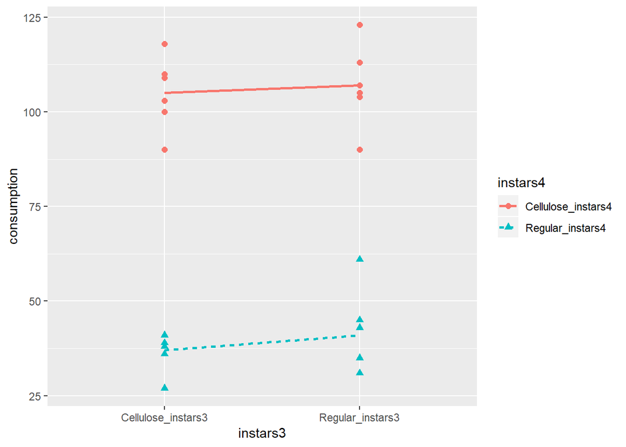

```r
ggplot(hornworms, aes(x = instars3 ,
                    y = consumption,
                    shape = instars4,
                    color = instars4,
                    group = instars4,
                    linetype = instars4)) +
  geom_point(size = 2) +
  geom_smooth(method = "lm", se = 0)
```

## Exercise3

*This is problem C2 on page 387 of your textbook. Using the data in Table 9.9, enter all of the data in R, and compute averages for all basic factors of interest.*

```r
words<- data.frame(Recall = c(60,52,20,36,40,36,36,44,36,52,44,32,32,32,32,20,40,64,40,52,60,44,40,44,52,28,32,44,32,64,44,28,24,36,44,40,28,64,56,60), abcon = c(rep("abstract", 20),                                  rep("concrete",20)),
                    finf = c(rep("frequent",10), rep("infrequent",10),rep("frequent",10), rep("infrequent",10)) )
```

```r
ex3<-favstats(Recall ~ abcon|finf, data = words)
ex3
```

```
##                  finf min Q1 median Q3 max mean       sd  n missing
## 1   abstract.frequent  20 36     38 50  60 41.2 11.32156 10       0
## 2   concrete.frequent  28 34     44 50  64 44.0 11.92570 10       0
## 3 abstract.infrequent  20 32     36 43  64 38.8 12.37201 10       0
## 4 concrete.infrequent  24 30     42 53  64 42.4 14.00952 10       0
## 5            frequent  20 36     42 52  64 42.6 11.40821 20       0
## 6          infrequent  20 32     40 46  64 40.6 12.99555 20       0
```

## Exercise4

*Create an interaction graph. Is there evidence of an interaction between the two basic factors* There is no interaction between the factors since the blue line and the red line are parallel to each other, meaning that the frequency level does not influence the impact of abstract level on remembering the words.

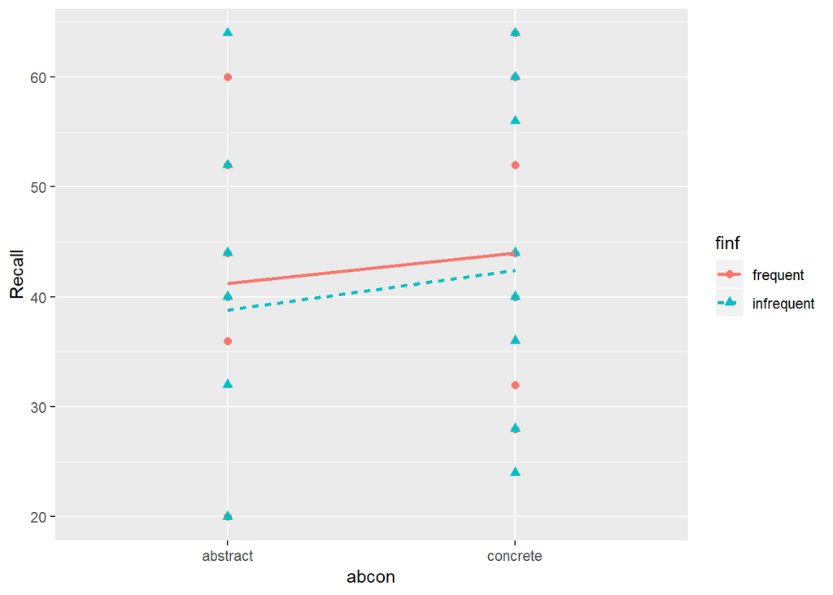

```r
ggplot(words, aes(x = abcon,
                    y = Recall,
                    shape = finf,
                    color = finf,
                    group = finf,
                    linetype = finf)) +
  geom_point(size = 2) +
  geom_smooth(method = "lm", se = 0)
```

## Exercise5

*Problem D2 on page 396 of your textbook. Enter the summary data into R just as shown above for the schizophrenia data. Answer the question asked in problem D2*

```r
schizophrenia <- data.frame(resp_time = c(78, 56, 25, 25,
                                          44, 28, 25, 23),
                            diagnosis = c(rep("schizophrenic", 4), rep("normal", 4)),
                            slope = rep(c("steep", "flat"), 4),
                            instructions = c(rep("free", 2), rep("idiosyncratic", 2),
                                             rep("free", 2), rep("idiosyncratic", 2)))
```